# Subsampling 33k PBMCs

Harm Brugge

16-3-2017

Investigation of how sub-sampling interferes mean expression

Load the data

```r
load("../data/seurat_33k_main")
```

Subset major cell types

```r
pbmc33k.subset <- SubsetData(pbmc33k.merged, ident.use = c("B", "NK", "TH", "TC", "Monocytes"))
pbmc33k.subset <- BuildClusterTree(pbmc33k.subset, do.reorder = T)
```

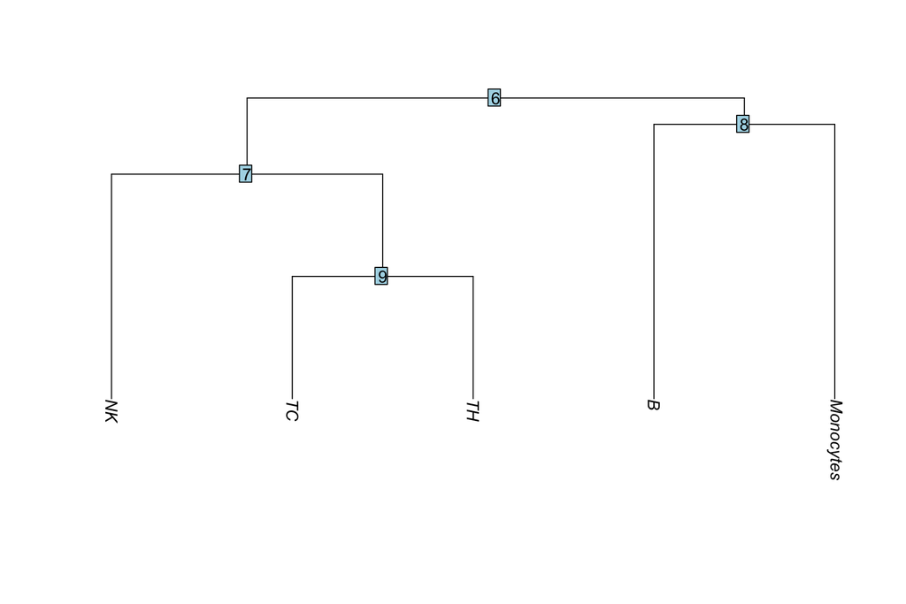

```r
rm(pbmc33k.merged)
```

This function subsets the expression data into the desired number of groups and applies a function (by default the mean) over each row (gene) of the subset. The resulting vector of this function is added to a matrix. So the returned matrix by default is a matrix containing the mean expression of every gene inside a sub-sample.

```r
subset <- function(exp.data, group.count, FUN=mean, ...) {

  group.size <- floor(ncol(exp.data) / group.count)

  samples.result <- matrix(0L, nrow = nrow(exp.data), ncol = group.count, dimnames = list(row.names(exp.data), NULL))

  for (i in 1:group.count) {
    random.cols <- sample(1:ncol(exp.data), group.size) # Random index of number of columns
    random.sample <- exp.data[,random.cols] # Use indices for random subset
    samples.result[,i] <- apply(random.sample,1, function(row) FUN(row, ...)) # Apply the function over each row and add it to the matrix
    exp.data <- exp.data[,-random.cols] # Remove the used random data for next itteration
  }

  samples.result <- t(samples.result)
  samples.result <- samples.result[,order(colSums(samples.result), decreasing = T )] # Order on totals

  return(samples.result)
}
```

## TH cells

Subset the TH cells, remove the blank rows and divide them up in groups of 33

```r
th.cells <- SubsetData(pbmc33k.subset, ident.use = c("TH"))
filtered.data <- th.cells@data[apply(th.cells@data, 1, function(x) !all(x==0)),]
samples.mean <- subset(exp.data = filtered.data, group.count = 33)
```

Mean expression of CD3E on the 33 subsamples. The avarage expression ranges from 1.45-1.65

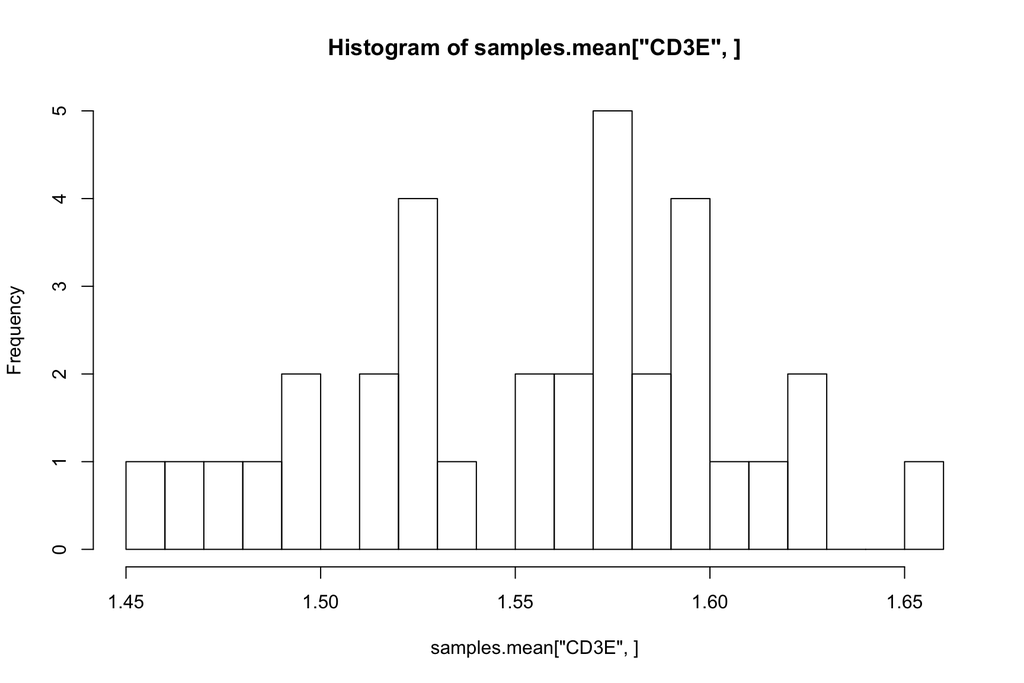

```r
hist(samples.mean["CD3E",], breaks = 20)
```

```r
mean.total <- rowSums(samples.mean)
#samples.mean.sd <- apply(samples.mean, 1, sd)
```

A few boxplots of the distribution of mean expression of a gene across the sub-samples.

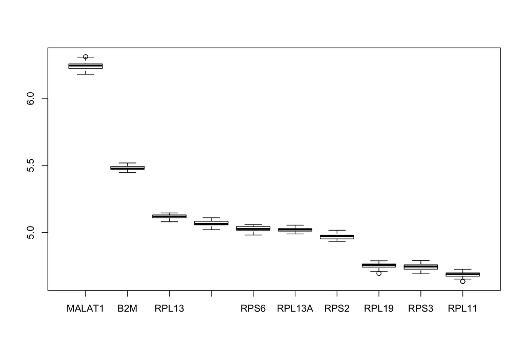

```r
boxplot(samples.mean[,1:10], outline=T)
```

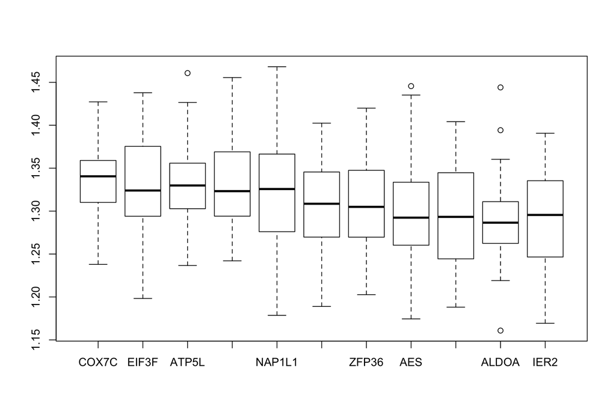

```r
boxplot(samples.mean[,200:210], outline=T)
```

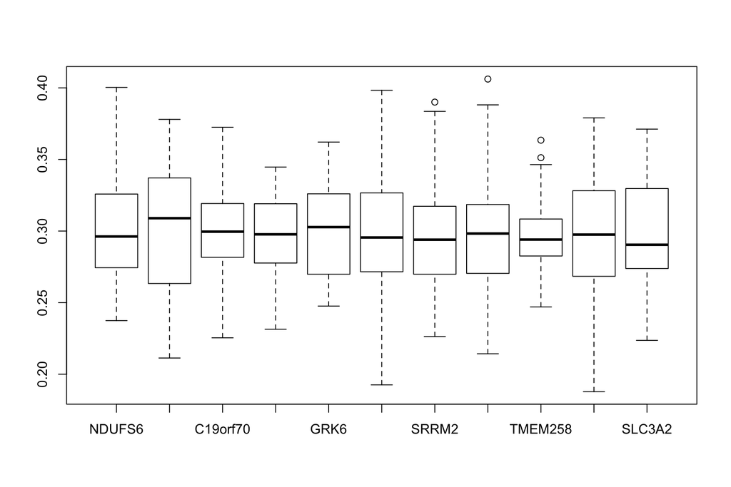

```r
boxplot(samples.mean[,1000:1010], outline=T)
```

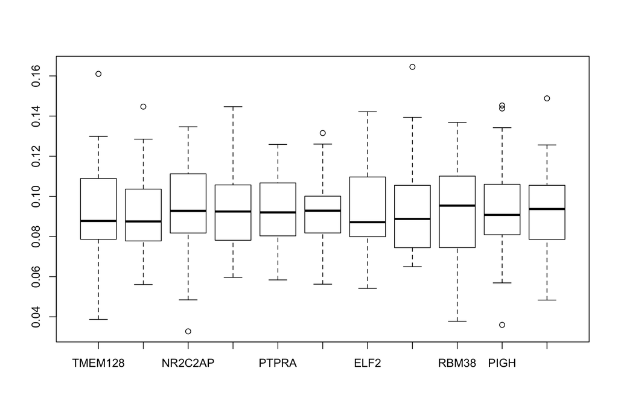

```r
boxplot(samples.mean[,3000:3010], outline=T)
```

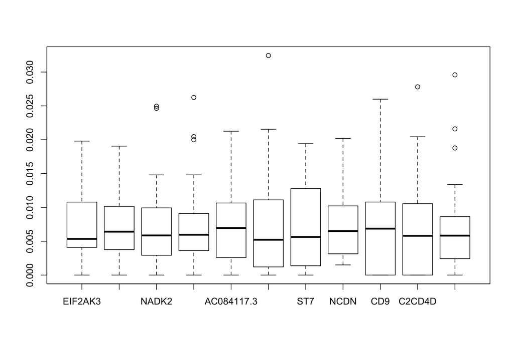

```r
boxplot(samples.mean[,10000:10010], outline=T)
```

## B cells.

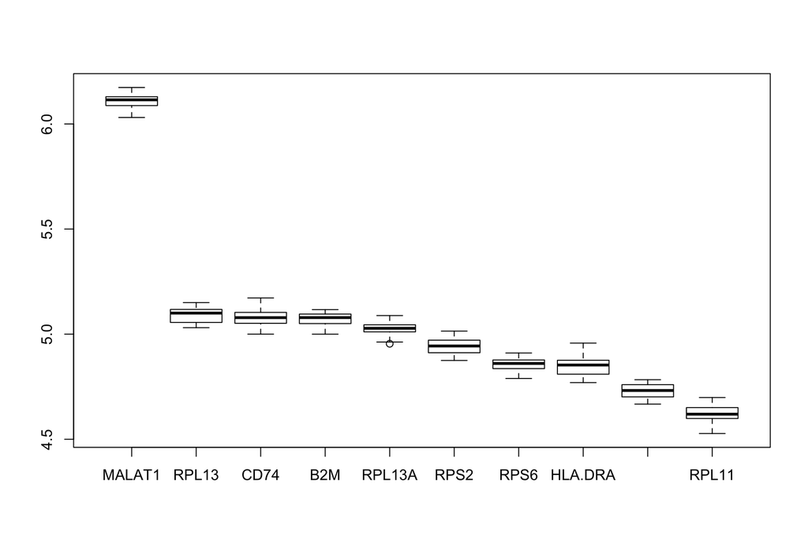

```r
b.cells <- SubsetData(pbmc33k.subset, ident.use = c("B"))
b.filtered <- b.cells@data[apply(b.cells@data, 1, function(x) !all(x==0)),]
b.samples.mean <- subset(exp.data = b.filtered, group.count = 33)

boxplot(b.samples.mean[,1:10], outline=T)
```

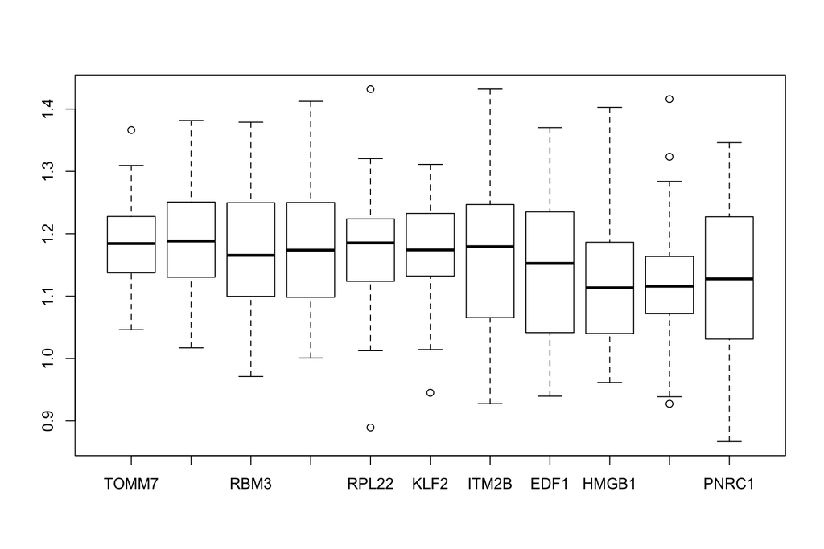

```r
boxplot(b.samples.mean[,200:210], outline=T)
```

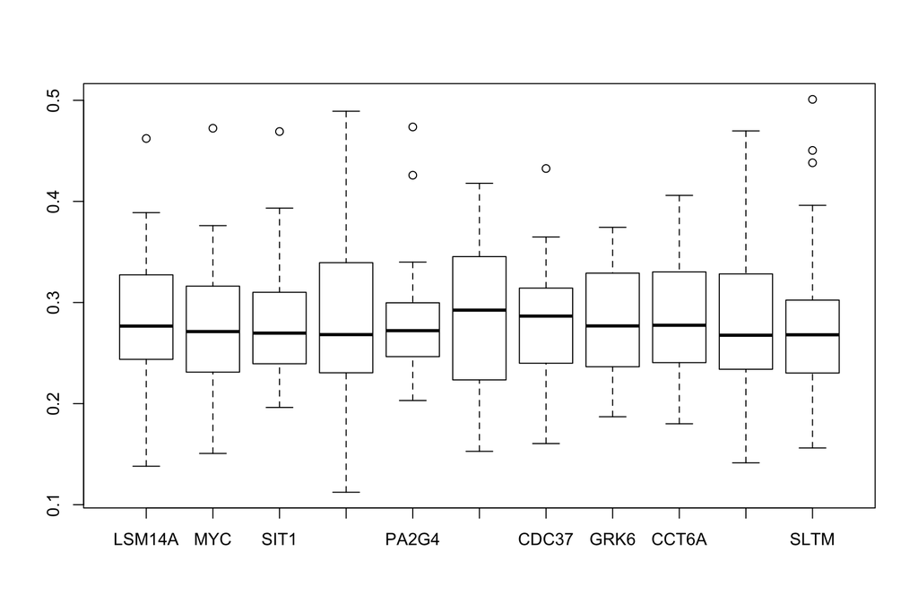

```r
boxplot(b.samples.mean[,1000:1010], outline=T)
```

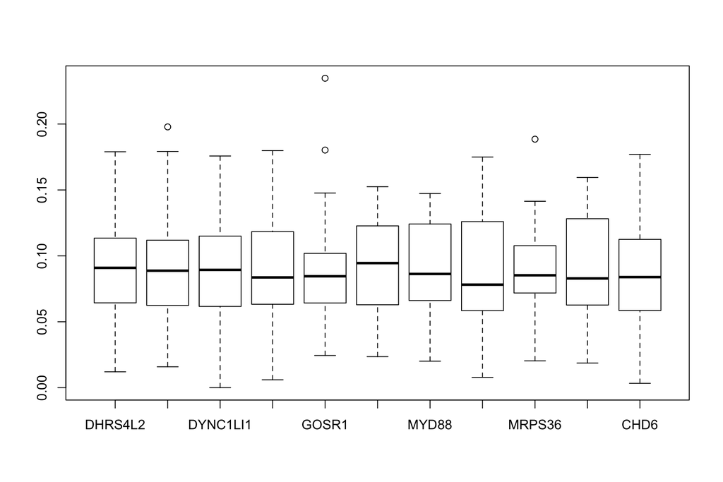

```r
boxplot(b.samples.mean[,3000:3010], outline=T)
```

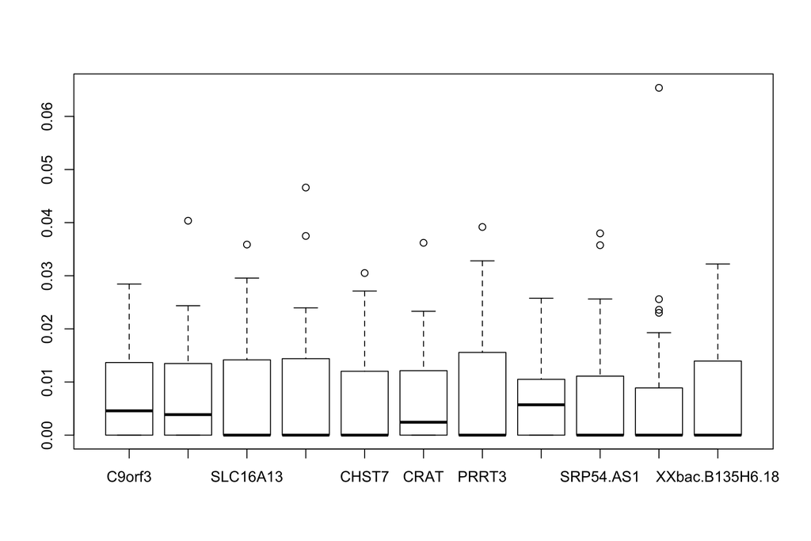

```r
boxplot(b.samples.mean[,10000:10010], outline=T)
```

## Median (weighted)

A function that takes the median of the non-zero elements and multiplies it by the fraction non-zero elements.

```r
nzmedian.weighted <- function(x) {
  zvals <- x==0
  if (all(zvals)) 0 else median(x[!zvals]) * sum(!zvals) / length(x)
}

b.median.weighted <- subset(exp.data = b.filtered, group.count = 33, nzmedian.weighted)
```

The boxplots on the left show the distribution of the mean within the samples, the plots on the rights used the weighted median function. Not really any difference

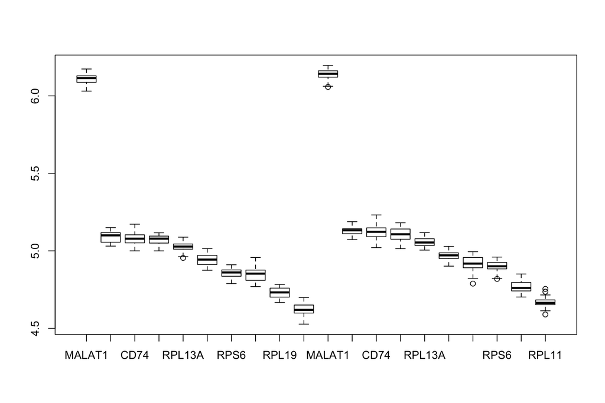

```r
boxplot(cbind(b.samples.mean[,1:10], b.median.weighted[,1:10]), outline=T)
```

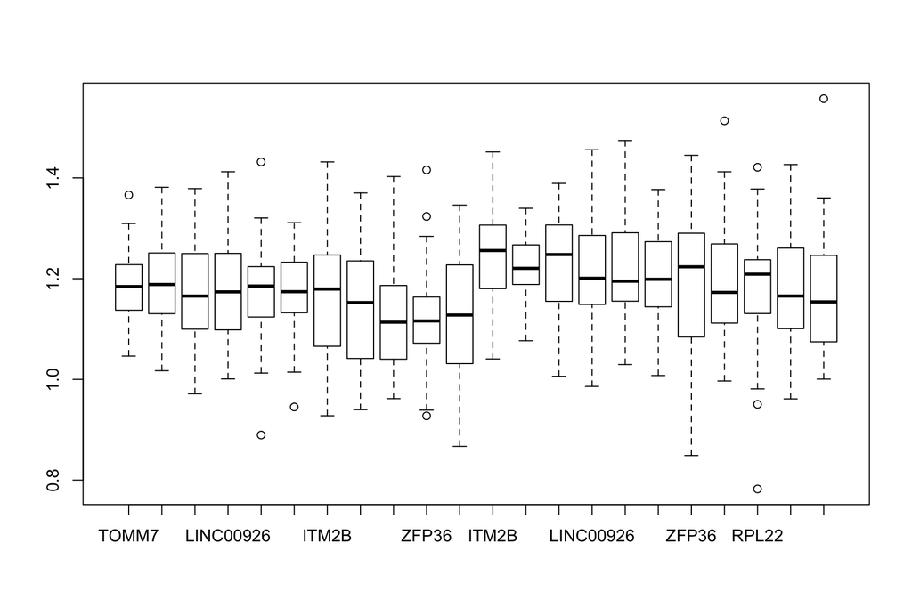

```r
boxplot(cbind(b.samples.mean[,200:210], b.median.weighted[,200:210]), outline=T)
```

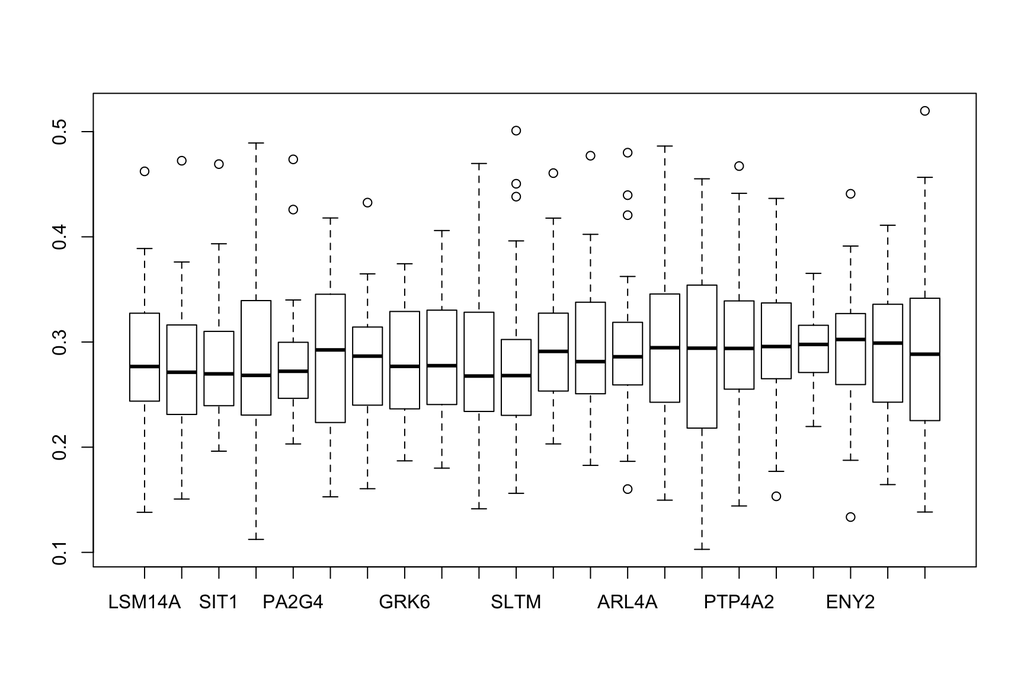

```r
boxplot(cbind(b.samples.mean[,1000:1010], b.median.weighted[,1000:1010]), outline=T)
```

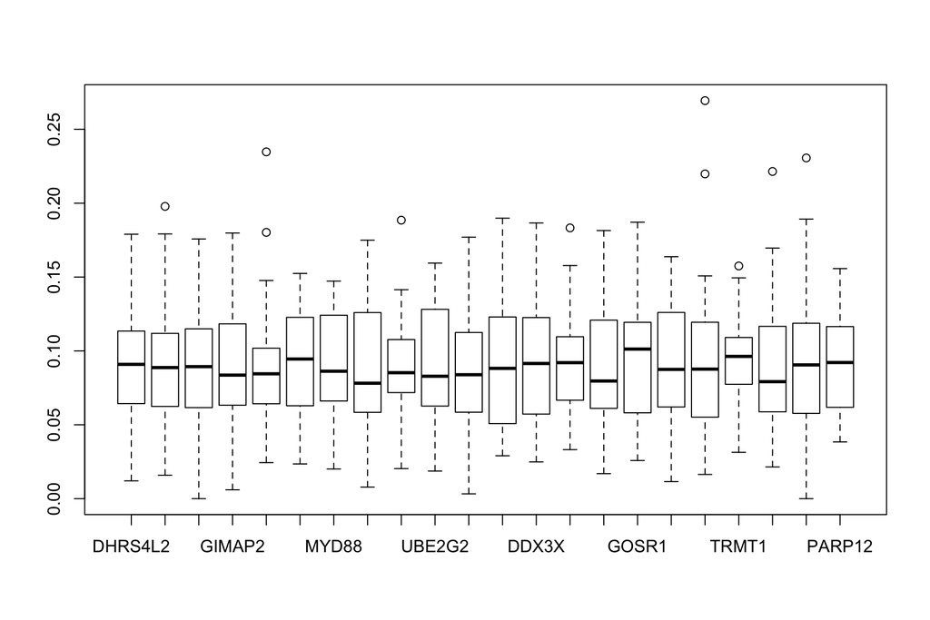

```r
boxplot(cbind(b.samples.mean[,3000:3010], b.median.weighted[,3000:3010]), outline=T)
```

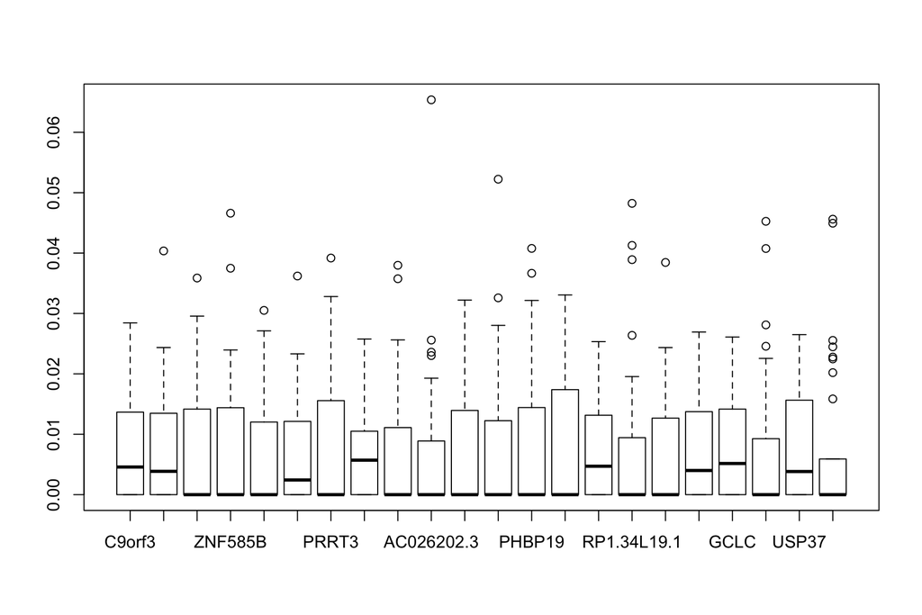

```r
boxplot(cbind(b.samples.mean[,10000:10010], b.median.weighted[,10000:10010]), outline=T)
```

## Quantile

Here we take the 75% quantile

```r
b.median.quant.75 <- subset(exp.data = b.filtered, group.count = 33, FUN = quantile, 0.75)
```

Compare them to the boxplots of the mean

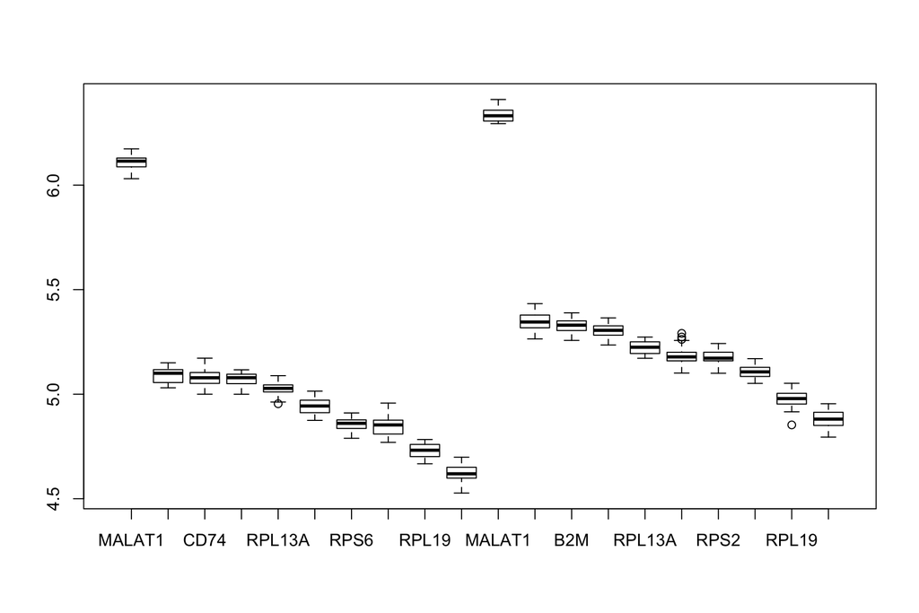

```r
boxplot(cbind(b.samples.mean[,1:10], b.median.quant.75[,1:10]), outline=T)
```

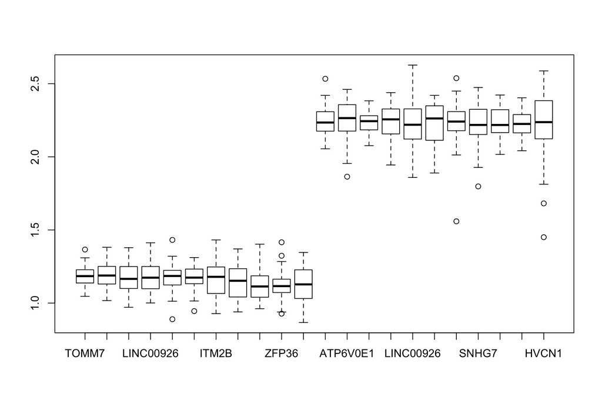

```r
boxplot(cbind(b.samples.mean[,200:210], b.median.quant.75[,200:210]), outline=T)
```

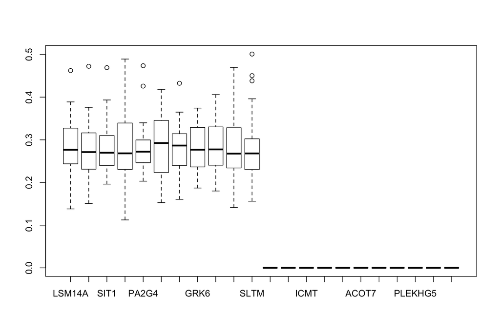

```r
boxplot(cbind(b.samples.mean[,1000:1010], b.median.quant.75[,1000:1010]), outline=T)
```

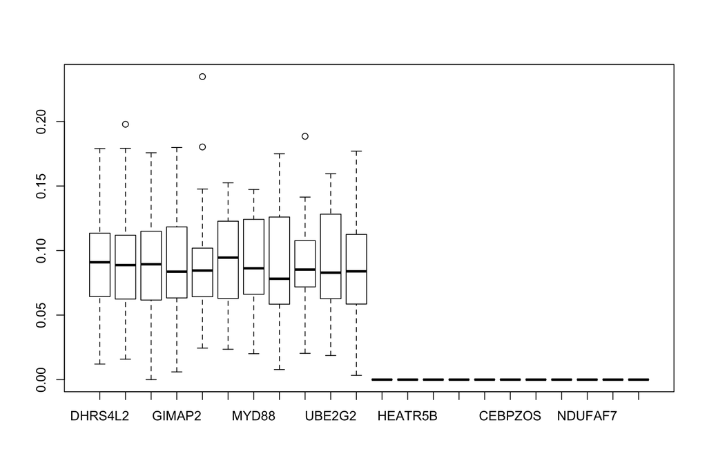

```r
boxplot(cbind(b.samples.mean[,3000:3010], b.median.quant.75[,3000:3010]), outline=T)
```

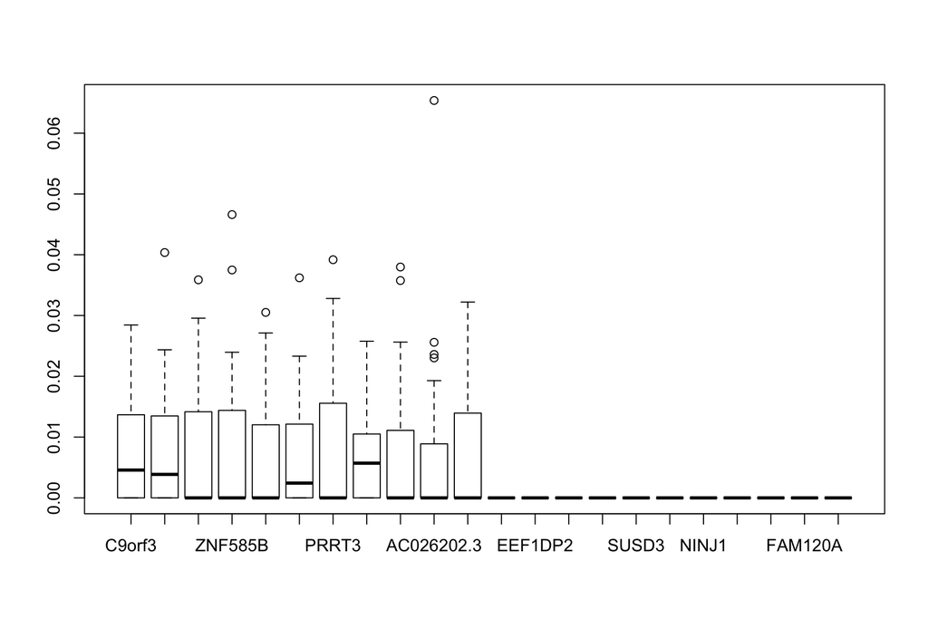

```r
boxplot(cbind(b.samples.mean[,10000:10010], b.median.quant.75[,10000:10010]), outline=T)
```

## 90%

```r
b.median.quant.9 <- subset(exp.data = b.filtered, group.count = 33, FUN = quantile, 0.9)
```

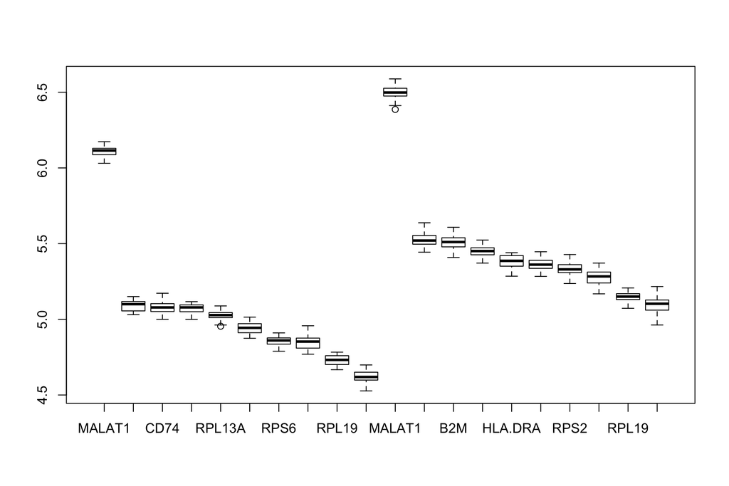

```r
boxplot(cbind(b.samples.mean[,1:10], b.median.quant.9[,1:10]), outline=T)
```

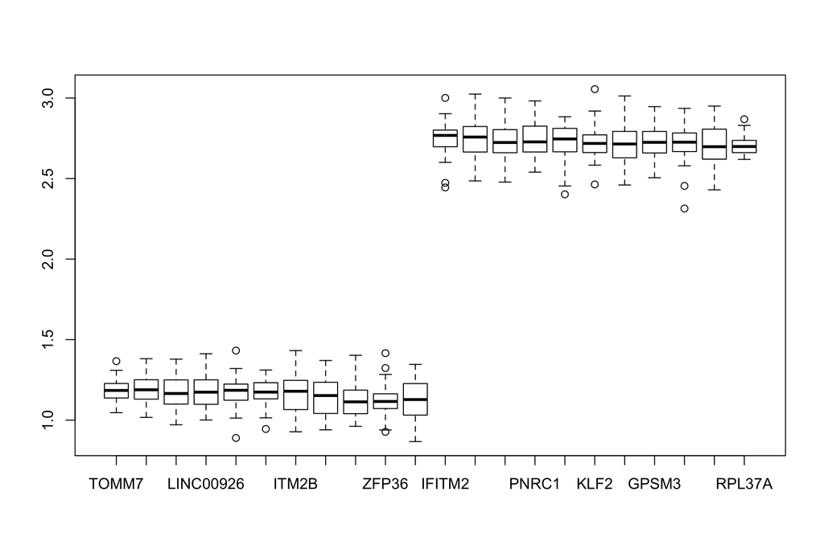

```r
boxplot(cbind(b.samples.mean[,200:210], b.median.quant.9[,200:210]), outline=T)
```

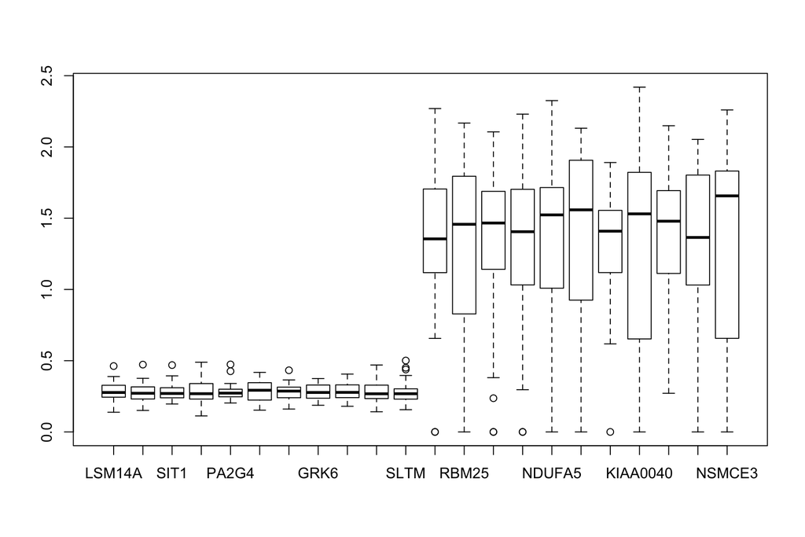

```r
boxplot(cbind(b.samples.mean[,1000:1010], b.median.quant.9[,1000:1010]), outline=T)
```

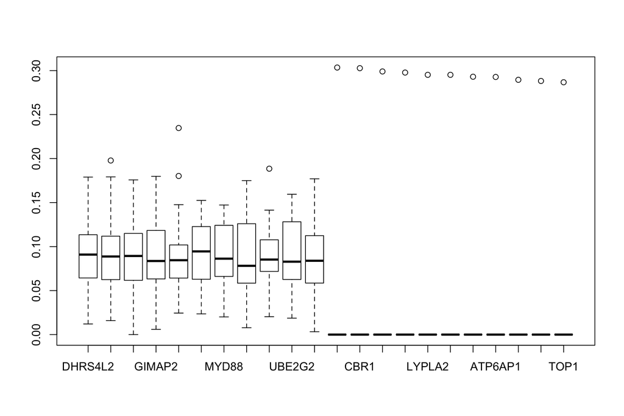

```r
boxplot(cbind(b.samples.mean[,3000:3010], b.median.quant.9[,3000:3010]), outline=T)
```

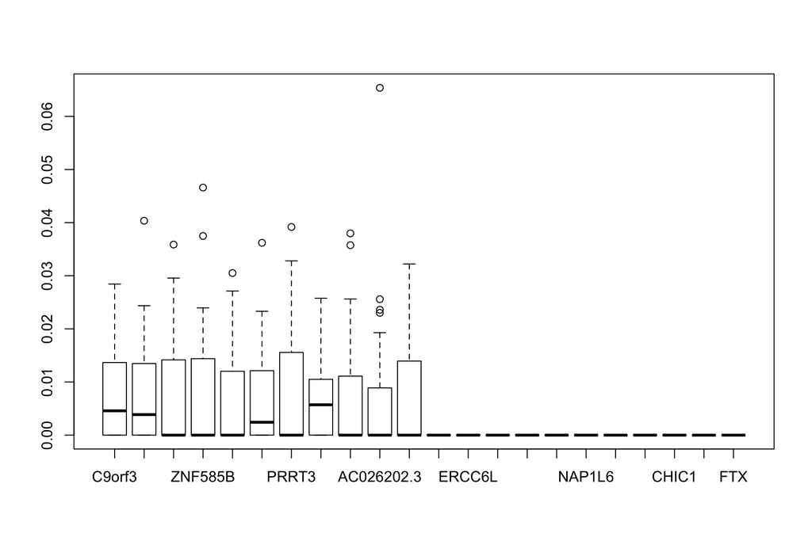

```r
boxplot(cbind(b.samples.mean[,10000:10010], b.median.quant.9[,10000:10010]), outline=T)
```